# DNM vs Alignment Comparison

Jake Prasad

Tuesday, July 28, 2015

[output not shown]

[output not shown]

```r
smoothalign <- function(df,sm,align="logodds") {
  if (align=="logodds") {
    return(log(df$ba+sm)-log(df$ba+df$nba+2*sm)-log(df$bna+sm)+log(df$bna+df$nbna+2*sm))
  } else if (align=="subodds") {
    return((df$ba+sm)/(df$ba+df$nba+2*sm)-(df$bna+sm)/(df$bna+df$nbna+2*sm))
  } else if (align=="logdnm") {
    return(log(df$ba+sm)-log(df$ba+df$nba+2*sm)-log(df$bna+df$ba+sm)+log(df$nba+df$ba+df$bna+df$nbna+2*sm))
  } else if (align=="subdnm") {
    return((df$ba+sm)/(df$ba+df$nba+2*sm)-(df$bna+df$ba+sm)/(df$nba+df$ba+df$bna+df$nbna+2*sm))
  } else {
    stop("Invalid alignment type.")
  }
}

d$lo1 <- smoothalign(d,1,"logodds")
d$sd0 <- smoothalign(d,0,"subdnm")

stopifnot(max(abs(d$lo1-d$pyalign))<.00001)
stopifnot(max(abs(d$sd0-d$dnm))<.00001)
```

Alignment (Verified/NonVerified):

Our standard measure for alignment uses Verified/Not verified as a power proxy. Using Verified/Not verified, we’re able to clearly see that an influential speaker/uninfluential replier pair results in a stronger alignment than an uninfluential speaker/influential replier pair.

```r
subsetted <- subset(df,logdnmalignment!="FALSE"&(ba+nba)>5&(bna+nbna)>5)
subsetted = transform(subsetted,logdnmalignment=as.numeric(logdnmalignment))
```

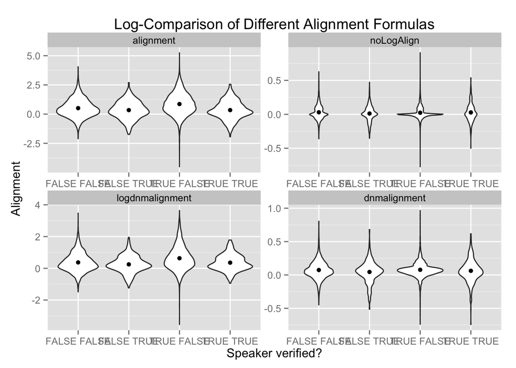

```r
d2 <- subsetted %>%
  group_by(verifiedSpeaker,speakerId,replierId) %>%
  summarize(convs=n(), alignment=alignment, vreply=verifiedReplier, dnmalignment=dnmalignment, noLogAlign=noLogAlign, logdnmalignment=logdnmalignment) %>%
  gather(alignmentType,alignmentValue,c(alignment, dnmalignment, logdnmalignment, noLogAlign))

levels(d2$alignmentType)=c("alignment","noLogAlign","logdnmalignment","dnmalignment")

ggplot(d2,aes(x=paste(verifiedSpeaker,vreply),y=alignmentValue)) + geom_violin() + labs(title="Log-Comparison of Different Alignment Formulas",x="Speaker verified?",y="Alignment") + facet_wrap(~ alignmentType, scales = "free") + stat_summary(geom="point",fun.y="mean")
```

Follower Bins:

The Echoes Of Power paper used follower count as a power proxy. If follower count isn’t a good power proxy it could explain why alignment wasn’t found. We bin follower counts for speaker and repliers and plot the results.

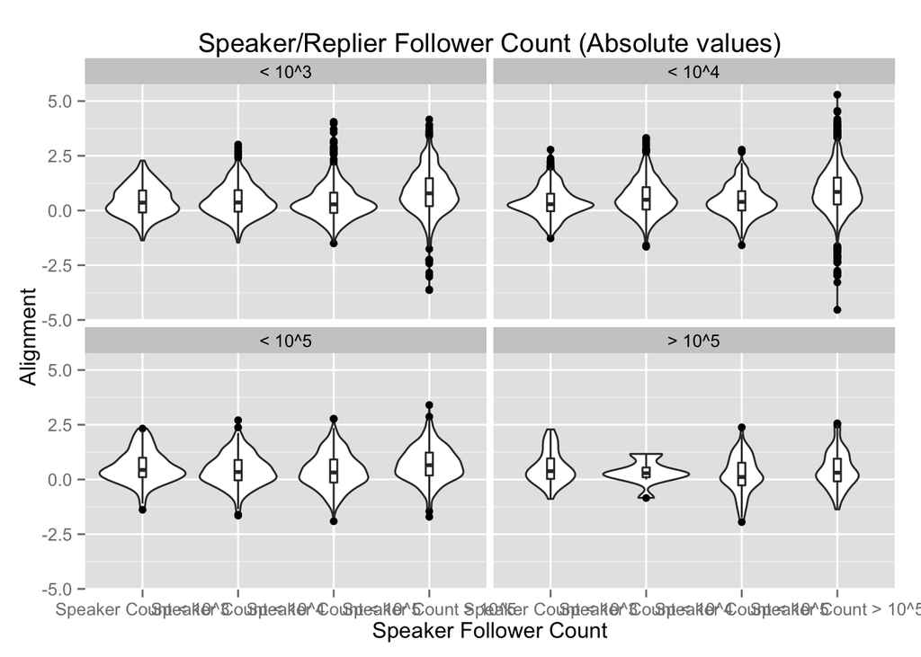

```r
d2 <- subset(df,logdnmalignment!="FALSE"&(ba+nba)>5&(bna+nbna)>5)
d2$speakerBins <- cut(d2$speakerFollowers, breaks=c(0,1000, 10000, 100000, 100000000), labels=c("Speaker Count < 10^3", "Speaker Count < 10^4", "Speaker Count < 10^5", "Speaker Count > 10^5"))
d2$replierBins <- cut(d2$replierFollowers, breaks=c(0,1000, 10000, 100000, 100000000), labels=c("< 10^3", "< 10^4", "< 10^5", "> 10^5"))
ggplot(d2,aes(x=paste(speakerBins),y=alignment)) + geom_violin() + labs(font=10, title="Speaker/Replier Follower Count (Absolute values)",x="Speaker Follower Count",y="Alignment") + facet_wrap(~ replierBins) + geom_boxplot(width=.1)
```

This is an interesting plot. It appears that follower count does have an effect on alignment. Let’s also try plotting the percent difference between speaker follower count and replier follower count.

```r
d2 <- subset(df,logdnmalignment!="FALSE"&(ba+nba)>5&(bna+nbna)>5)
subsetted <- transform(d2,logdnmalignment=as.numeric(logdnmalignment))
```

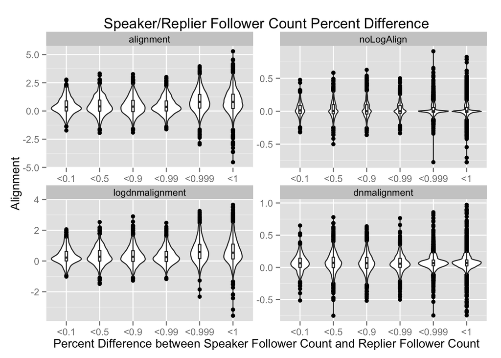

```r
d2 <- subsetted %>%
  group_by(verifiedSpeaker,speakerId,replierId) %>%
  summarize(convs=n(), alignment=alignment, vreply=verifiedReplier, dnmalignment=dnmalignment, noLogAlign=noLogAlign, logdnmalignment=logdnmalignment, percentDiff=percentDiff) %>%
  gather(alignmentType,alignmentValue,c(alignment, dnmalignment, logdnmalignment, noLogAlign))

d2$followerBins <- cut(d2$percentDiff, breaks=c(0,0.1,0.5,0.9, 0.99, 0.999, 1), labels=c("<0.1","<0.5", "<0.9", "<0.99", "<0.999", "<1"))

levels(d2$alignmentType)=c("alignment","noLogAlign","logdnmalignment","dnmalignment")

ggplot(d2,aes(x=followerBins,y=alignmentValue)) + geom_violin() + labs(title="Speaker/Replier Follower Count Percent Difference",x="Percent Difference between Speaker Follower Count and Replier Follower Count",y="Alignment") + facet_wrap(~ alignmentType, scales = "free") + geom_boxplot(width=.1)
```

This is also interesting. It appears like alignment could follow a parabolic curve insteaed of a linear one. Let’s also look at alignment by marker

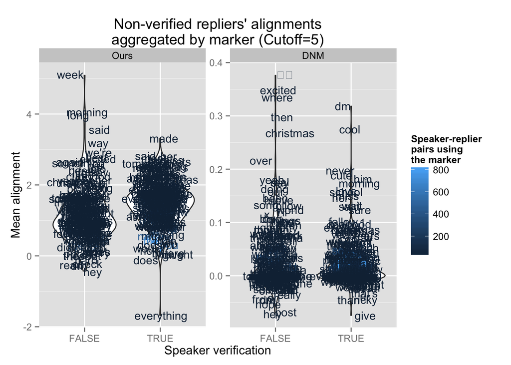

```r
d2 <- d %>%
  filter(vreply==F,(ba+nba)>=5,(bna+nbna)>=5) %>%
  group_by(vspeak,category) %>%
  #filter(convs<50) %>%
  summarize(convs=n(),Ours=mean(lo1),DNM=mean(sd0)) %>%
  gather(alignment,mean,Ours,DNM)

ggplot(d2,aes(x=vspeak,y=mean,color=convs,label=category)) + geom_violin() + geom_text(position=position_jitter(w=0.2),size=4) + labs(title="Non-verified repliers' alignments\naggregated by marker (Cutoff=5)",x="Speaker verification",y="Mean alignment",color="Speaker-replier\npairs using\nthe marker") + facet_wrap(~ alignment,scales="free") + theme_grey()
```

Hmm, from the given plot, it seems the DNM formula is prone to outliers among individual markers. Why might this be the case? First we pot alignment values against number of conversations to make sure our intuition is correct

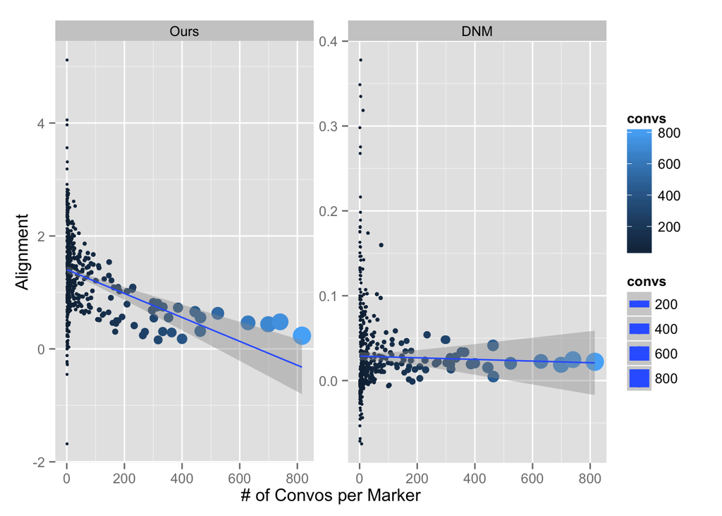

```r
subsetted <- subset(d2)
ggplot(subsetted,aes(x=convs,y=mean,size=convs,color=convs,label=category)) + geom_point() + facet_wrap(~alignment, scales="free") + labs(y="Alignment",x="# of Convos per Marker") + geom_smooth(method=lm)
```

This is surprising. It appears that OUR formula is actually the one that’s prone to outliers. Let’s see if we can correct this

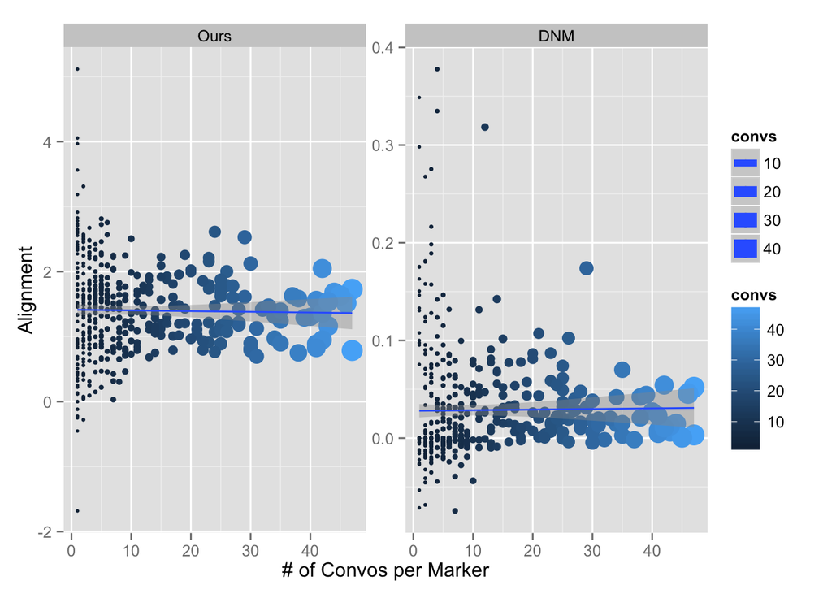

```r
subsetted <- subset(d2) %>%
  filter(convs<50)

ggplot(subsetted,aes(x=convs,y=mean,size=convs,color=convs,label=category)) + geom_point() + facet_wrap(~alignment, scales="free") + labs(y="Alignment",x="# of Convos per Marker") + geom_smooth(method=lm)
```

Ok, so it seems that markers with convs < 50 don’t correspond to number of conversations. Let’s replot the markers vs. alignment chart taking this new knowledge into account:

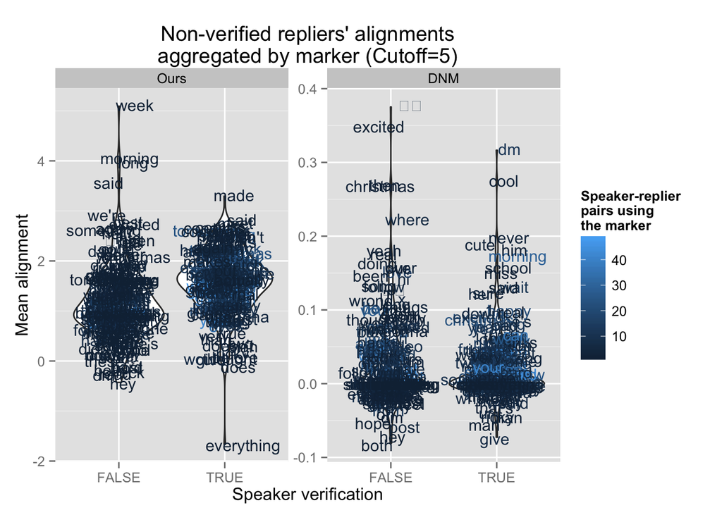

```r
d2 <- d %>%
  filter((ba+nba)>=5&(bna+nbna)>=5) %>%
  group_by(vspeak,category) %>%

  summarize(convs=n(),Ours=mean(lo1),DNM=mean(sd0)) %>%
  filter(convs<50) %>%
  gather(alignment,mean,Ours,DNM)

ggplot(d2,aes(x=vspeak,y=mean,color=convs,label=category)) + geom_violin() + geom_text(position=position_jitter(w=0.2),size=4) + labs(title="Non-verified repliers' alignments\naggregated by marker (Cutoff=5)",x="Speaker verification",y="Mean alignment",color="Speaker-replier\npairs using\nthe marker") + facet_wrap(~ alignment,scales="free") + theme_grey()
```

Ok, we got rid of the error with love. It’s still surprising that we’re seeing so many outliers. There’s also a correspondence with utterances and alignment. Let’s see if that effect’s still exists witht he newly added convs<50 filter.

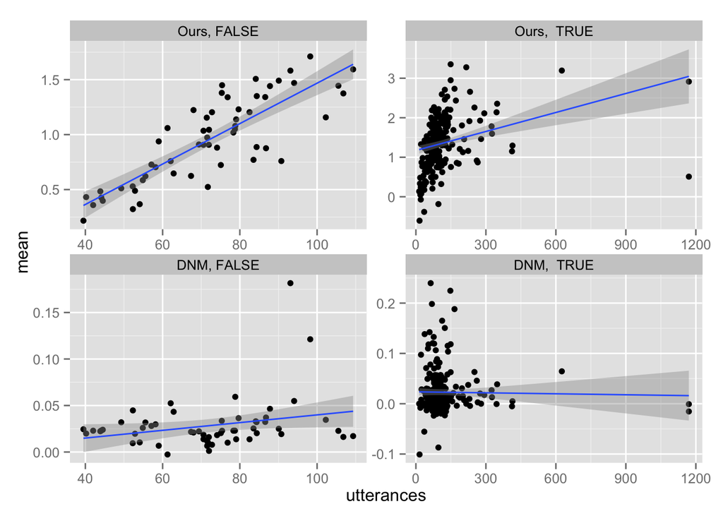

```r
d2 <- d %>%
  filter((ba+nba)>5&(bna+nbna)>5) %>%
  group_by(category) %>%
  summarize(utterances=mean(numUtterances),convs=n(),Ours=mean(lo1),DNM=mean(sd0),thresh=n()<50) %>%
  gather(alignment,mean,Ours,DNM)

ggplot(d2,aes(x=utterances,y=mean))+geom_point() + facet_wrap(alignment~thresh,scales="free") + geom_smooth(method=lm)
```

Ok, we’re definitely decreasing our alignment to utterances correlation by filtering out convos < 50. However, we still see a slight correlation to # of utterances. Let’s try to filter by # of utterances and # of convos this time.

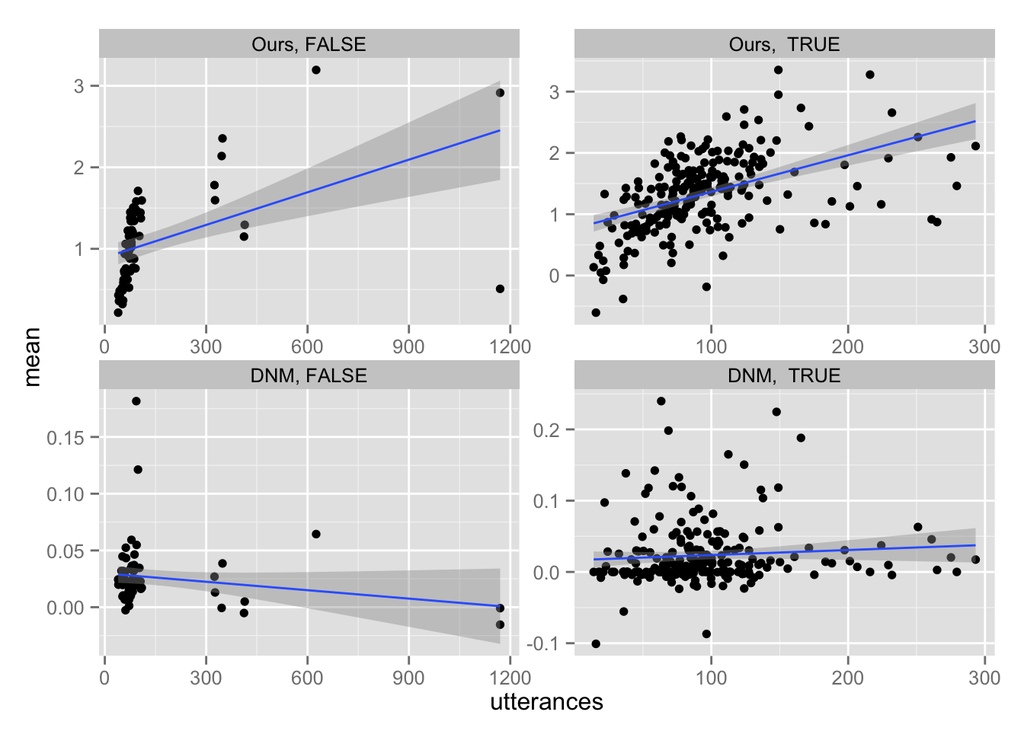

```r
d2 <- d %>%
  filter((ba+nba)>5&(bna+nbna)>5) %>%
  group_by(category) %>%
  summarize(utterances=mean(numUtterances),convs=n(),Ours=mean(lo1),DNM=mean(sd0),thresh=n()<50&mean(numUtterances)<300) %>%
  gather(alignment,mean,Ours,DNM)

ggplot(d2,aes(x=utterances,y=mean))+geom_point() + facet_wrap(alignment~thresh,scales="free") + geom_smooth(method=lm)
```

This is definitely troubling…It appears that there’s no way to filter by # of utterances per marker, because there is a very clear correlation. How do we fix this??? Let’s first think about why number of utterances with the marker may impact alignment.

Our formula is alignment = log(ba/(ba+nba))-log(bna/(bna+nbna))

As number of utterances a says with the marker -> INF,

alignment = log(ba/INF)-log(bna/0) = log(0)-log(INF) = -INF - INF = -INF

As number of utterances a says without the marker -> 0.

alignment = log(ba/0)-log(bna/INF) = log(INF)-log(0) = INF - (-INF) = INF

How the results in the above calculations relates to the plot is kind of confusing. Since we’ve already filtered out common markers, markers are rarely said in utterances. What this means is that as # of utterances increases, the percentage of utterances with markers decreases, leading to higher alignment. How do we account for this?

One thing we could do is just do by marker calculations instead of trying to aggregate. However, there should be a better solution that not aggregating.

How about we aggregate by comparing the difference in alignments for each marker (i.e. instead of averaging alignments for verified speakers per marker and comparing it to average unverified speaker alignments per marker we average the difference in alignments between verified and unverified speakers per marker).

Let’s try it out!

```r
d2 <- d %>%
  filter((ba+nba)>5&(bna+nbna)>5) %>%
  filter(((vspeak==TRUE&vreply==FALSE)|(vspeak==FALSE&vreply==TRUE))) %>%

  group_by(category,vreply,vspeak) %>%
  summarize(category=category,utterances=mean(numUtterances),convs=n(),Ours=mean(lo1),DNM=mean(sd0),vspeak=vspeak,vreply=vreply) %>%
  gather(alignment,mean,Ours,DNM) %>%
  filter(alignment=="Ours")
```

```
## Duplicate column names found in molten data.table. Setting unique names using 'make.names'
```

[figure not shown]

```r
ggplot(d2,aes(x=vspeak,y=mean))+geom_point() + facet_wrap(~category,scales="free")
```

# compare

Loading the most recent results.

Cleaning down the data table:

```r
d <- df[,list(ba=ba,nba=nba,bna=bna,nbna=nbna,
              vspeak=verifiedSpeaker,vreply=verifiedReplier,
              sid=speakerId,rid=replierId,category=category,
              pyalign=alignment,percentDiff=percentDiff),]
```

Calculating alignments in R to check against the python alignments; stop if the summary has a max absolute difference greater than 1e-05

```r
smoothalign <- function(df,sm) {
  return(log(df$ba+sm)-log(df$ba+df$nba+2*sm)-log(df$bna+sm)+log(df$bna+df$nbna+2*sm))
}

smoothalignold <- function(df,sm) {
  return((df$ba+sm)/(df$ba+df$nba+2*sm)-(df$bna+df$ba+sm)/(df$nba+df$ba+df$bna+df$nbna+2*sm))
}

d$sm0 <- smoothalign(d,0)
d$sm1 <- smoothalign(d,1)
d$osm0 <- smoothalignold(d,0)

max(abs(d$sm1-d$pyalign))
```

```
## [1] 1.776357e-15
```

We plot 2 histograms of 1) Verified speakers talking to an unverified repliers 2) Unverified speakers talking to verified repliers

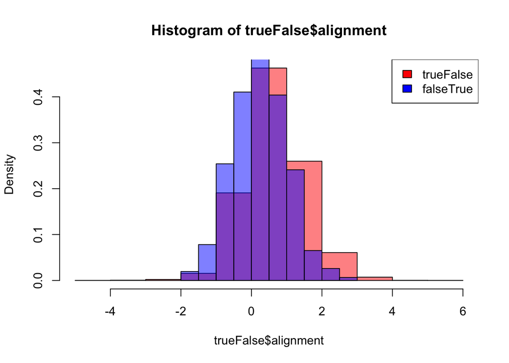

```r
trueFalse <- subset(df,powerDenom>5&baseDenom>5&verifiedSpeaker=="TRUE"&verifiedReplier=="FALSE")
falseTrue <- subset(df,powerDenom>5&baseDenom>5&verifiedSpeaker=="FALSE"&verifiedReplier=="TRUE")
hist(trueFalse$alignment,col=rgb(1,0,0,0.5),freq=F)
hist(falseTrue$alignment, add=T,col=rgb(0,0,1,0.5),freq=F)
legend("topright", c("trueFalse", "falseTrue"), fill=c("red", "blue"))
```